# GLMs for Car Insurance Pricing: Initial Data Exploration

Mick Cooney

13 July 2016

# 1 Load Data

```r
### Set up the data
data(freMTPLfreq)
data(freMTPLsev)
data(freMTPL2freq)
data(freMTPL2sev)

policy1_dt <- copy(freMTPLfreq)
claims1_dt <- copy(freMTPLsev)
policy2_dt <- copy(freMTPL2freq)
claims2_dt <- copy(freMTPL2sev)

setDT(policy1_dt)
setDT(claims1_dt)
setDT(policy2_dt)
setDT(claims2_dt)

rm(freMTPLfreq)
rm(freMTPLsev)
rm(freMTPL2freq)
rm(freMTPL2sev)

setnames(policy1_dt, c('policy_id','claim_count','exposure','power','car_age'
                      ,'driver_age','brand','gas','region','density'))
print(policy1_dt)
```

```
##         policy_id claim_count   exposure power car_age driver_age
##      1:         1           0 0.09000000     g       0         46
##      2:         2           0 0.84000000     g       0         46
##      3:         3           0 0.52000000     f       2         38
##      4:         4           0 0.45000000     f       2         38
##      5:         5           0 0.15000000     g       0         41
##     ---
## 413165:    413165           0 0.00273973     j       0         29
## 413166:    413166           0 0.00547945     d       0         29
## 413167:    413167           0 0.00547945     k       0         49
## 413168:    413168           0 0.00273973     d       0         41
## 413169:    413169           0 0.00273973     g       6         29
##                                      brand     gas region density
##      1: Japanese (except Nissan) or Korean  Diesel    R72      76
##      2: Japanese (except Nissan) or Korean  Diesel    R72      76
##      3: Japanese (except Nissan) or Korean Regular    R31    3003
##      4: Japanese (except Nissan) or Korean Regular    R31    3003
##      5: Japanese (except Nissan) or Korean  Diesel    R52      60
##     ---
## 413165: Japanese (except Nissan) or Korean  Diesel    R11    2471
## 413166: Japanese (except Nissan) or Korean Regular    R11    5360
## 413167: Japanese (except Nissan) or Korean  Diesel    R11    5360
## 413168: Japanese (except Nissan) or Korean Regular    R11    9850
## 413169: Japanese (except Nissan) or Korean  Diesel    R72      65
```

```r
setnames(claims1_dt, c('policy_id','claim_amount'))
print(claims1_dt)
```

```
##        policy_id claim_amount
##     1:     63987         1172
##     2:    310037         1905
##     3:    314463         1150
##     4:    318713         1220
##     5:    309380        55077
##    ---
## 16177:    302759           61
## 16178:    299443         1831
## 16179:    303389         4183
## 16180:    304313          566
## 16181:    206241         2156
```

# 2 Initial Data Exploration and Cleaning

Having loaded in the data, we want to look at the basic data types of the columns, along with row and columns counts. We also look at a quick summary of the data.

```r
str(policy1_dt)
```

```
## Classes 'data.table' and 'data.frame':   413169 obs. of  10 variables:
##  $ policy_id  : int  1 2 3 4 5 6 7 8 9 10 ...
##  $ claim_count: int  0 0 0 0 0 0 0 0 0 0 ...
##  $ exposure   : num  0.09 0.84 0.52 0.45 0.15 0.75 0.81 0.05 0.76 0.34 ...
##  $ power      : Factor w/ 12 levels "d","e","f","g",..: 4 4 3 3 4 4 1 1 1 6 ...
##  $ car_age    : int  0 0 2 2 0 0 1 0 9 0 ...
##  $ driver_age : int  46 46 38 38 41 41 27 27 23 44 ...
##  $ brand      : Factor w/ 7 levels "Fiat","Japanese (except Nissan) or Korean",..: 2 2 2 2 2 2 2 2 1 2 ...
##  $ gas        : Factor w/ 2 levels "Diesel","Regular": 1 1 2 2 1 1 2 2 2 2 ...
##  $ region     : Factor w/ 10 levels "R11","R23","R24",..: 9 9 5 5 6 6 9 9 5 1 ...
##  $ density    : int  76 76 3003 3003 60 60 695 695 7887 27000 ...
##  - attr(*, ".internal.selfref")=<externalptr>
```

```r
summary(policy1_dt)
```

```
##    policy_id       claim_count        exposure           power          car_age
##  Min.   :     1   Min.   :0.0000   Min.   :0.00273   f      :95718   Min.   :  0.00
##  1st Qu.:103293   1st Qu.:0.0000   1st Qu.:0.20000   g      :91198   1st Qu.:  3.00
##  Median :206585   Median :0.0000   Median :0.54000   e      :77022   Median :  7.00
##  Mean   :206585   Mean   :0.0392   Mean   :0.56109   d      :68014   Mean   :  7.53
##  3rd Qu.:309877   3rd Qu.:0.0000   3rd Qu.:1.00000   h      :26698   3rd Qu.: 12.00
##  Max.   :413169   Max.   :4.0000   Max.   :1.99000   j      :18038   Max.   :100.00
##                                                      (Other):36481
##    driver_age                                  brand             gas
##  Min.   :18.0   Fiat                              : 16723   Diesel :205945
##  1st Qu.:34.0   Japanese (except Nissan) or Korean: 79060   Regular:207224
##  Median :44.0   Mercedes, Chrysler or BMW         : 19280
##  Mean   :45.3   Opel, General Motors or Ford      : 37402
##  3rd Qu.:54.0   other                             :  9866
##  Max.   :99.0   Renault, Nissan or Citroen        :218200
##                 Volkswagen, Audi, Skoda or Seat   : 32638
##      region          density
##  R24    :160601   Min.   :    2
##  R11    : 69791   1st Qu.:   67
##  R53    : 42122   Median :  287
##  R52    : 38751   Mean   : 1985
##  R72    : 31329   3rd Qu.: 1410
##  R31    : 27285   Max.   :27000
##  (Other): 43290
```

We now create separate vectors for the numerical and categorical variables so we can automatically generate different exploratory plots of the data.

```r
vars_num <- c('claim_count','exposure','car_age','driver_age','density')

vars_cat <- c('power','brand','gas','region')
```

## 2.1 Univariate Data Exploration

We create simple univariate exploratory plots.

### 2.1.1 Numeric Variables

We iterate through the numeric variables, looking at a density plot for each one.

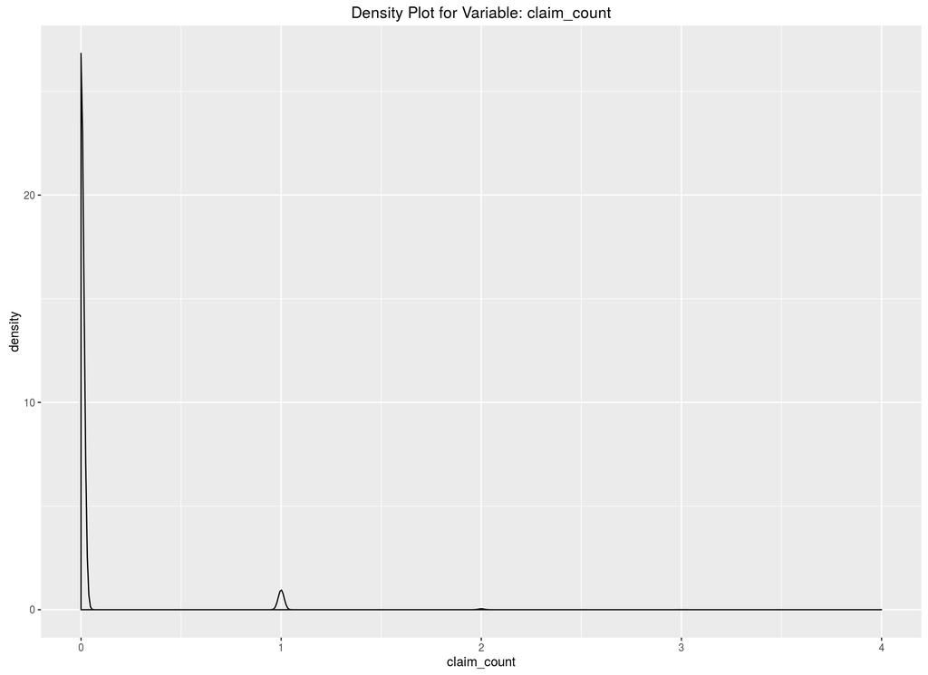

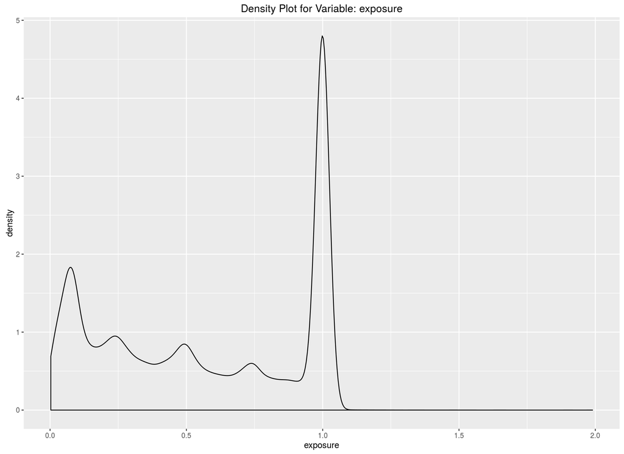

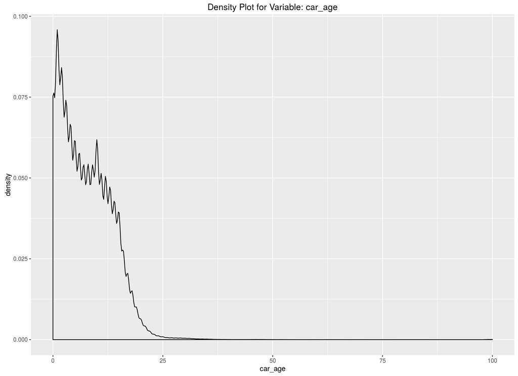

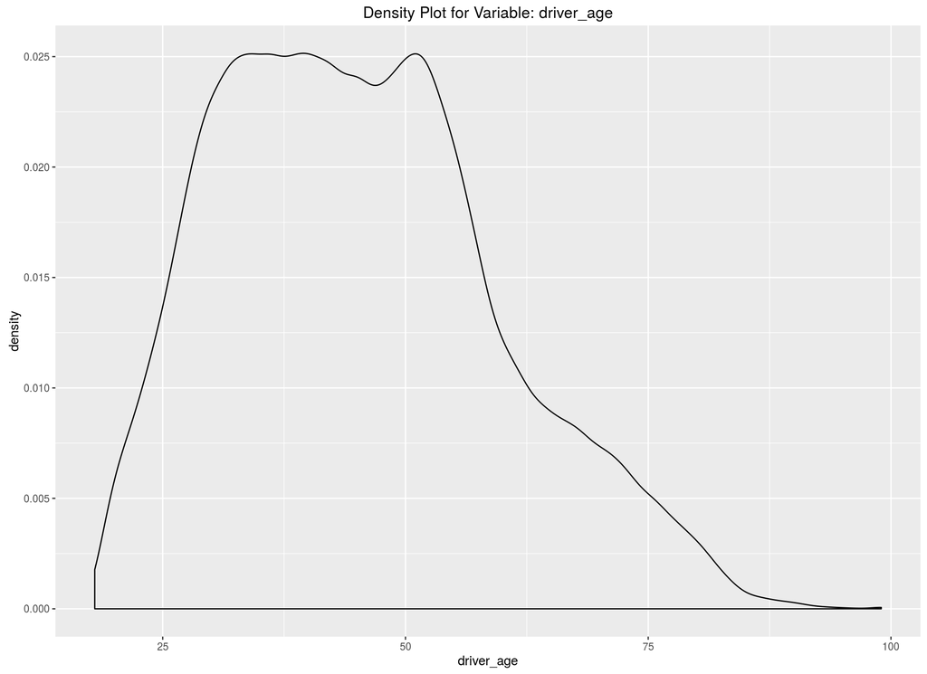

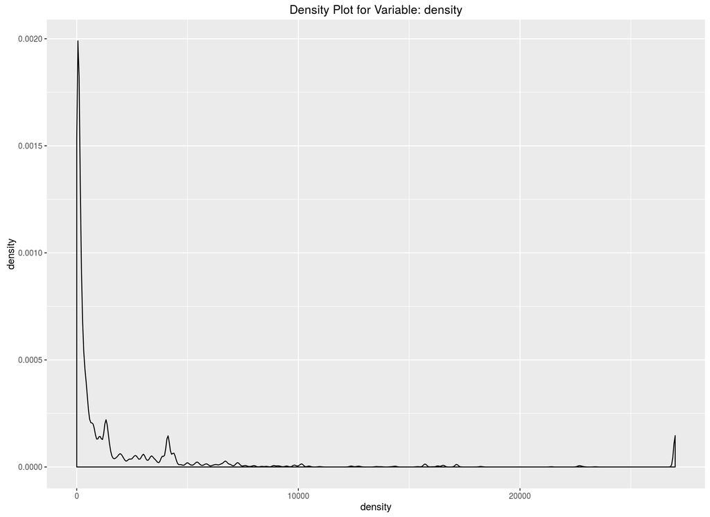

```r
for(plot_var in vars_num) {
    explore_plot <- ggplot() +
        geom_density(aes(x = policy1_dt[[plot_var]])) +
        xlab(plot_var) +
        ggtitle(paste0("Density Plot for Variable: ", plot_var))

    plot(explore_plot)
}
```

None of these plots seem very useful, so we try the same thing but now use histograms.

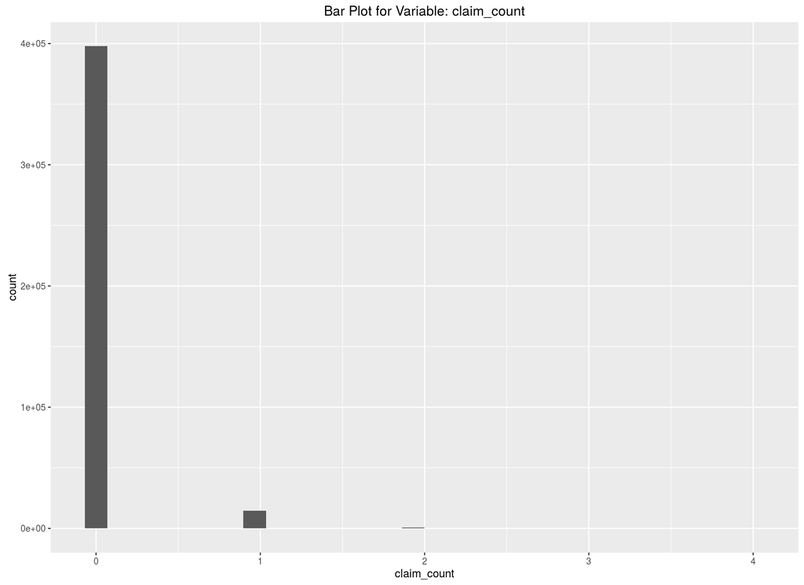

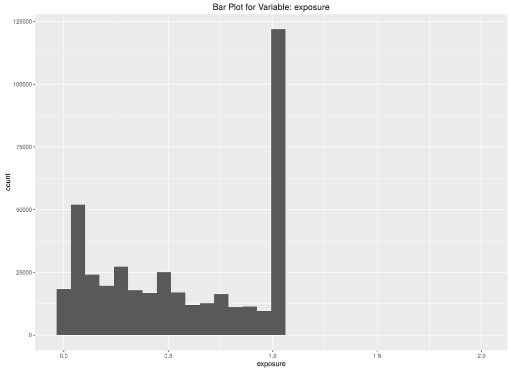

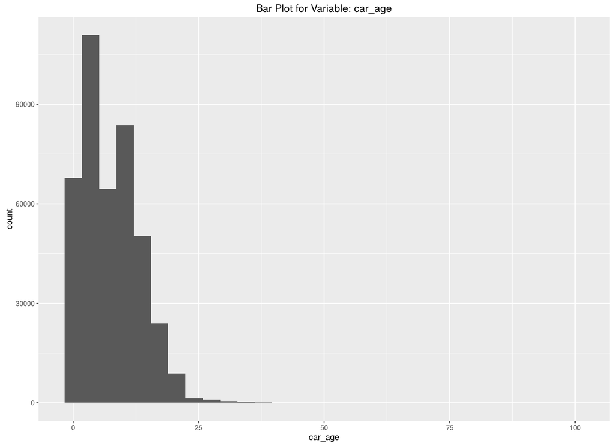

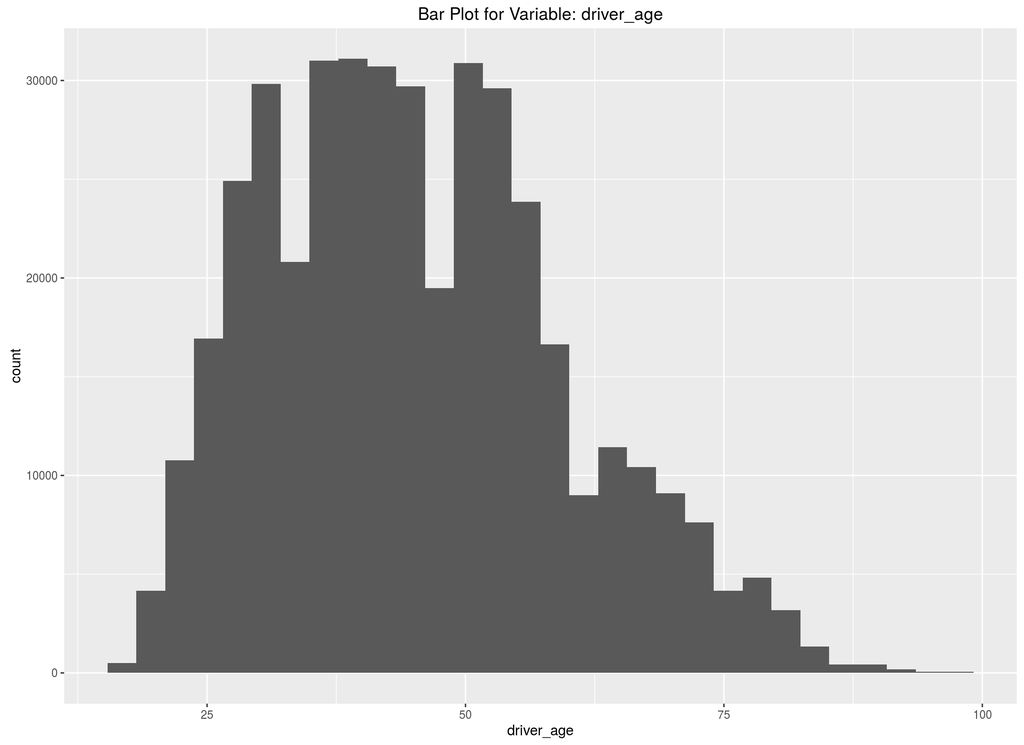

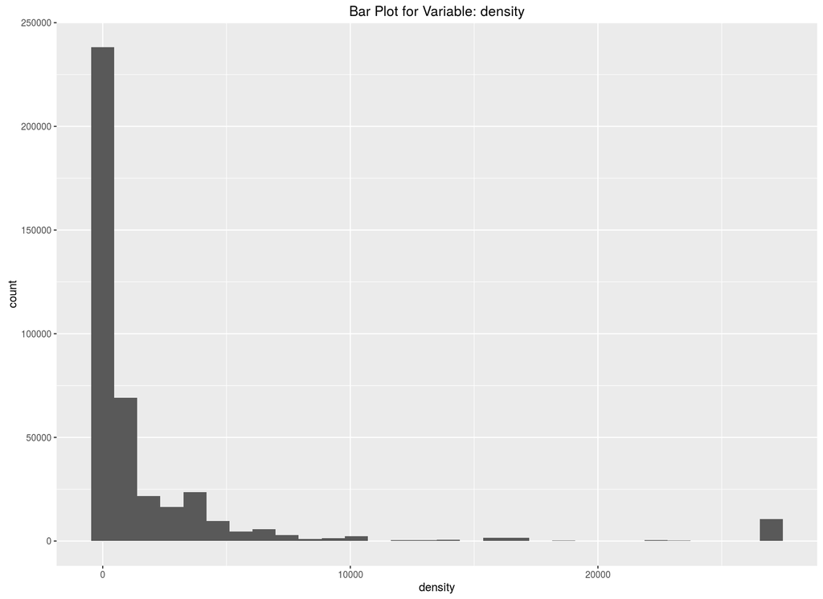

```r
for(plot_var in vars_num) {
    explore_plot <- ggplot() +
        geom_histogram(aes(x = policy1_dt[[plot_var]]), bins = 30) +
        xlab(plot_var) +
        ggtitle(paste0("Bar Plot for Variable: ", plot_var))

    plot(explore_plot)
}
```

### 2.1.2 Categorical Variables

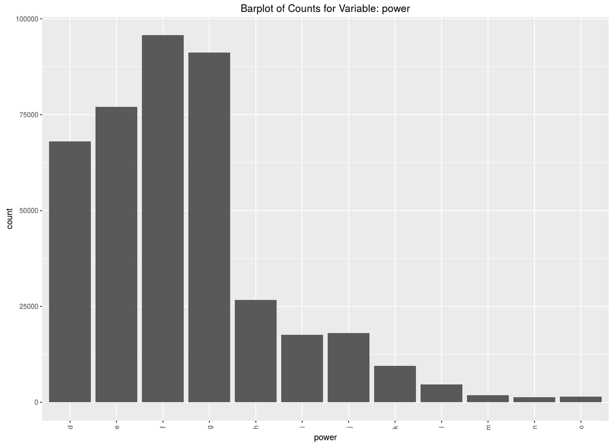

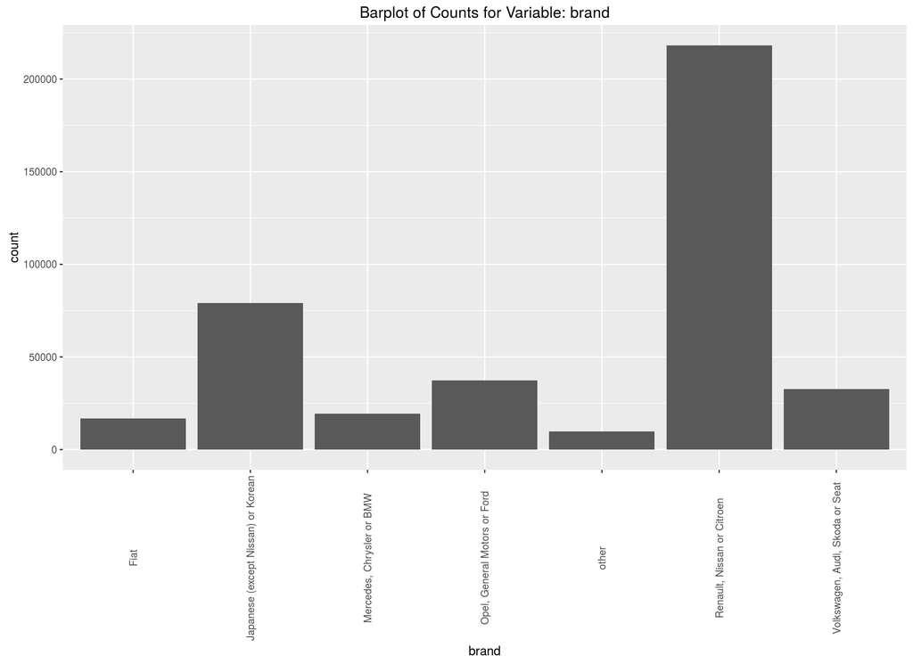

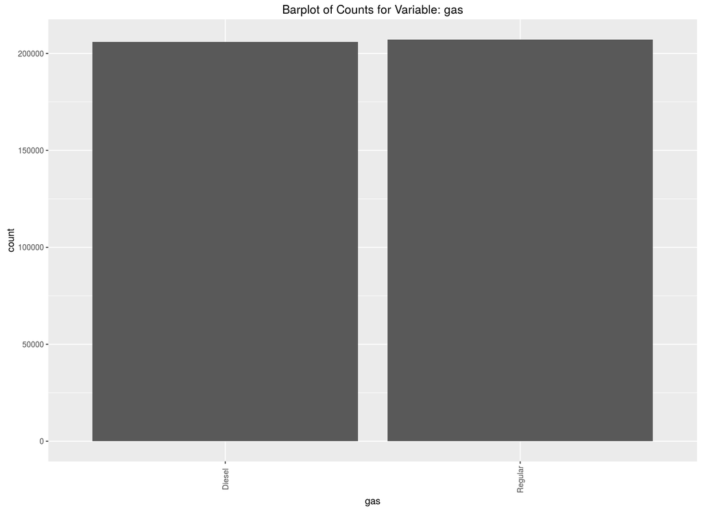

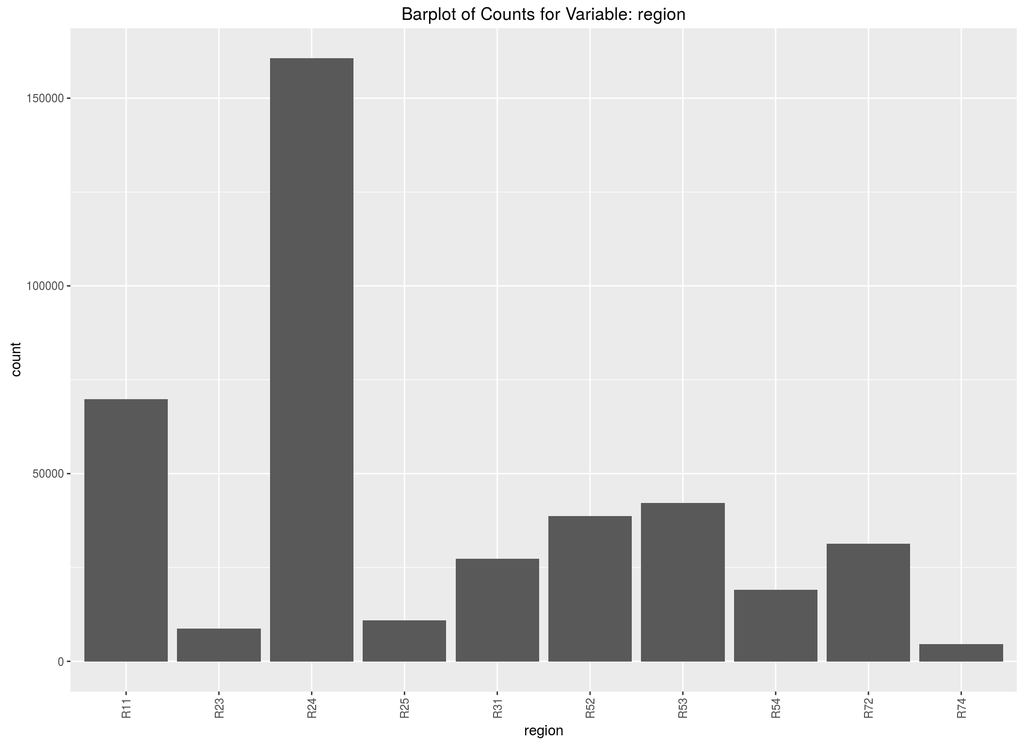

```r
for(plot_var in vars_cat) {
    explore_plot <- ggplot() +
        geom_bar(aes(x = policy1_dt[[plot_var]])) +
        xlab(plot_var) +
        ggtitle(paste0("Barplot of Counts for Variable: ", plot_var)) +
        theme(axis.text.x = element_text(angle = 90, vjust = 0.5))

    plot(explore_plot)
}
```

#### 2.1.2.1 exposure

The `exposure` variable is a bit strange - it seems strange to have policies whose duration is longer than a year in this book - but without knowledge of the business it is hard to tell. Let us see how the exposures that are longer than 1 year are distributed.

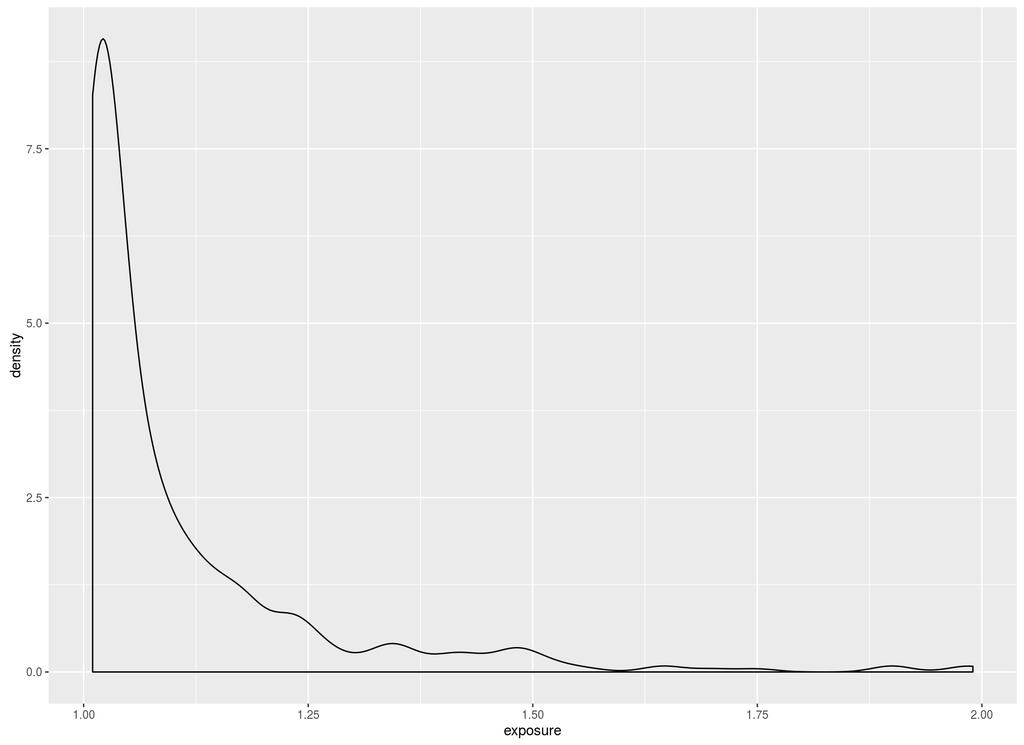

```r
ggplot(policy1_dt[exposure > 1]) +
    geom_density(aes(x = exposure))
```

We could remove these policies, but I am inclined to leave them in for the moment at least. We may need to revisit this decision later.

## 2.2 Bivariate Data Exploration

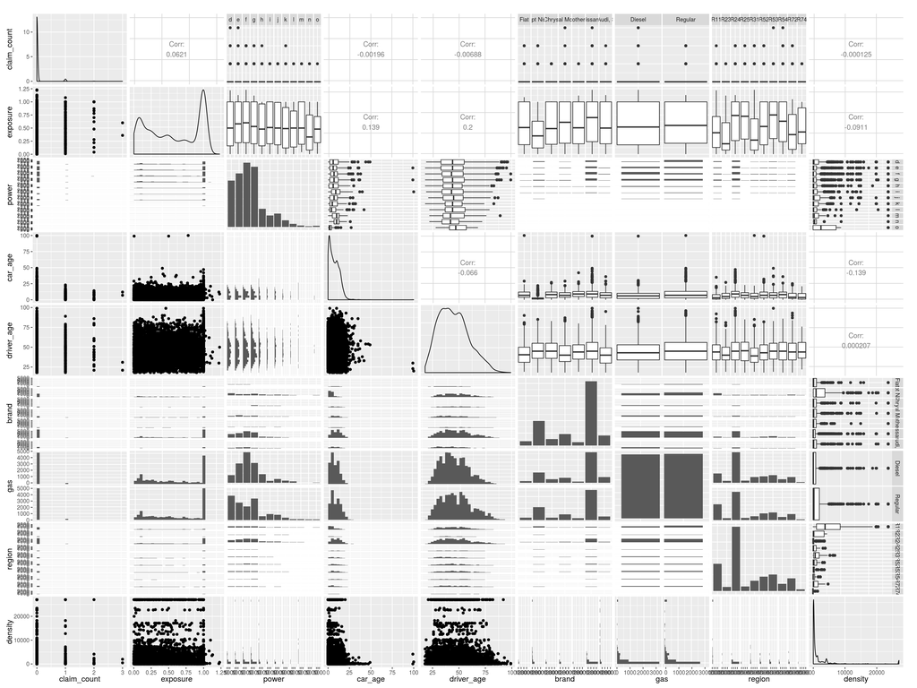

```r
pairsplot_count <- 10000

ggpairs(policy1_dt[, -1, with = FALSE][sample(1:.N, pairsplot_count, replace = FALSE)])
```

### 2.2.1 density vs region

Density seems a bit strange, so I want to see how density distributes across the regions as that also seems to be geographic.

First we look at boxplots:

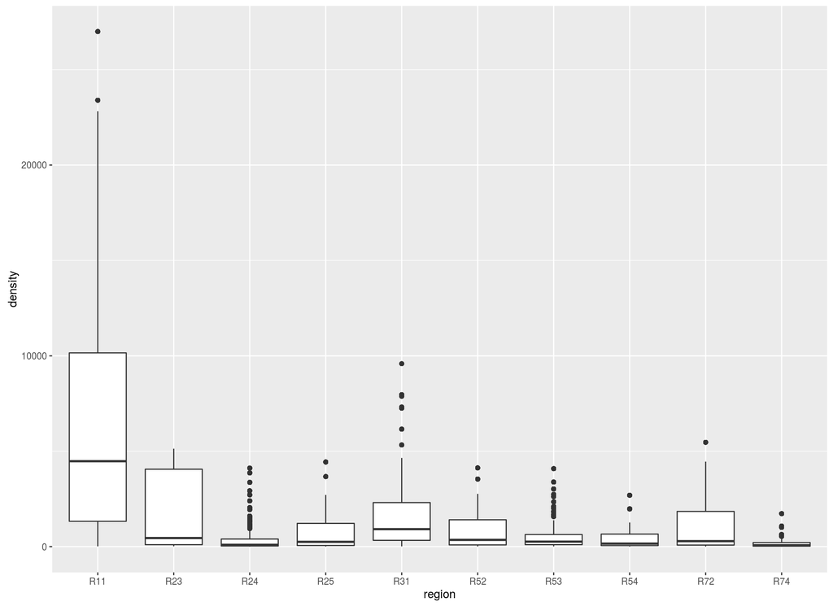

```r
ggplot(policy1_dt) +
    geom_boxplot(aes(x = region, y = density))
```

Then we do a facetted histogram, facetting by region.

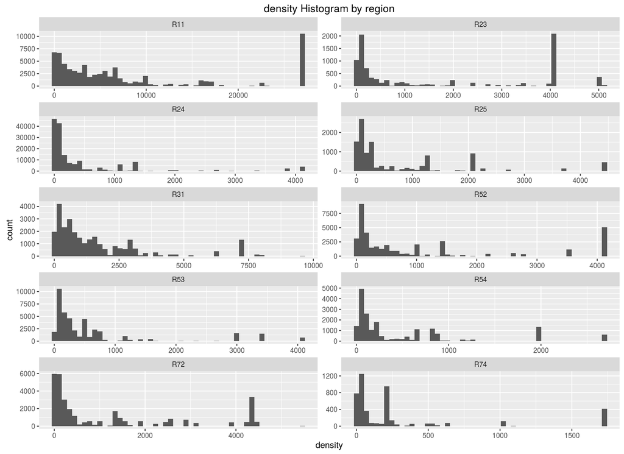

```r
ggplot(policy1_dt) +
    geom_histogram(aes(x = density), bins = 50) +
    facet_wrap(~region, scales = 'free', ncol = 2) +
    ggtitle("density Histogram by region")
```

### 2.2.2 claim_count vs region

We will look at `claim_count` vs `region` to see if there are any geographic patterns.

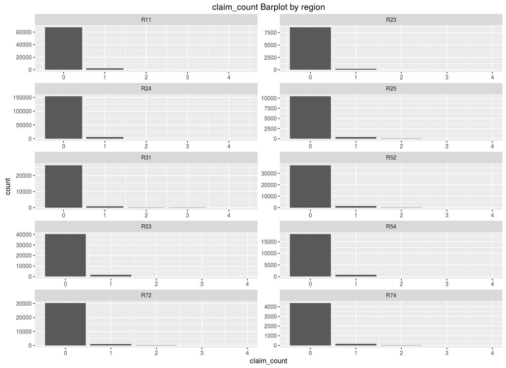

```r
ggplot(policy1_dt) +
    geom_bar(aes(x = claim_count)) +
    expand_limits(x = 4) +
    facet_wrap(~region, scales = 'free', ncol = 2) +
    ggtitle("claim_count Barplot by region")
```

We want to normalise these counts so we can see how many claims we get as a proportion of the policy count in each region, so to do this we first need to calculate this:

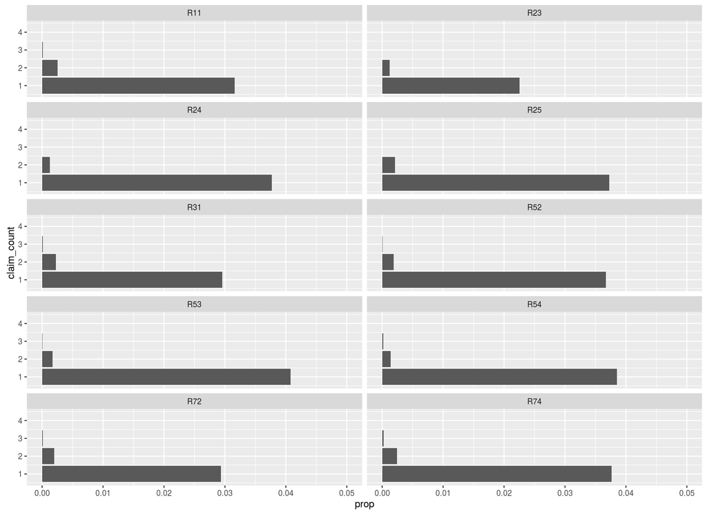

```r
policy_region_dt <- policy1_dt %>%
    group_by(region) %>%
    summarise(num_policies = length(policy_id))

policyprop_dt <- policy1_dt %>%
    left_join(policy_region_dt, 'region') %>%
    group_by(region, claim_count) %>%
    summarise(count = length(policy_id)
             ,prop  = length(policy_id) / max(num_policies))

ggplot(policyprop_dt[claim_count > 0]) +
    geom_bar(aes(x = claim_count, y = prop), stat = 'identity') +
    expand_limits(y = 0.05) +
    facet_wrap(~region, ncol = 2) +
    coord_flip()
```

```r
    ggtitle("Claim Proportion Barplot by region")
```

```
## $title
## [1] "Claim Proportion Barplot by region"
##
## attr(,"class")
## [1] "labels"
```

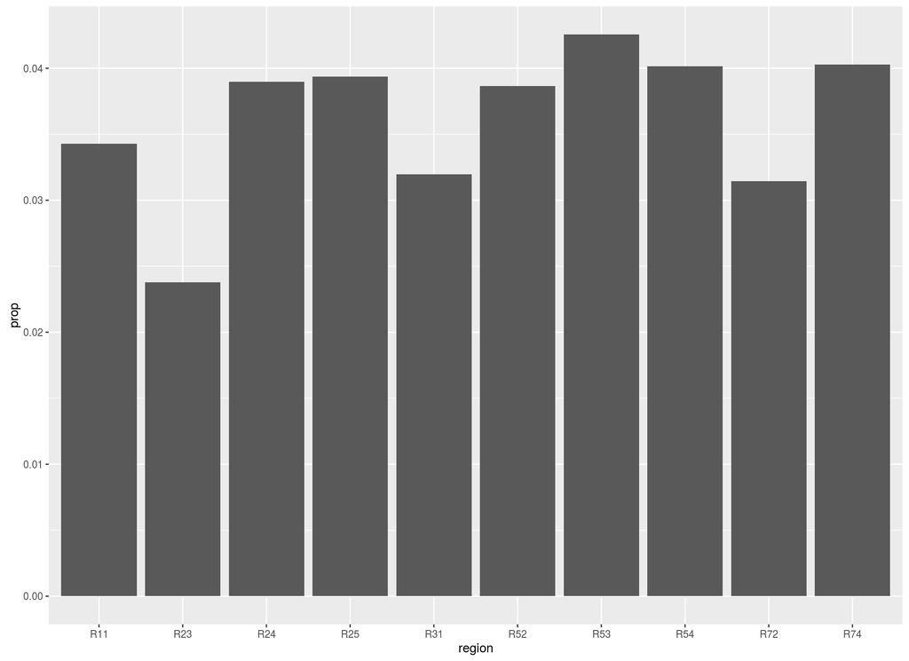

```r
ggplot(policyprop_dt[claim_count > 0]) +
    geom_bar(aes(x = region, y = prop), stat = 'identity') +
    expand_limits(x = unique(policyprop_dt$region))
```

```r
    facet_wrap(~claim_count, ncol = 2, scales = 'free')
```

```
## facet_wrap(claim_count)
```

```r
    ggtitle("Claim Proportion Barplot by region")
```

```
## $title
## [1] "Claim Proportion Barplot by region"
##
## attr(,"class")
## [1] "labels"
```

### 2.2.3 region vs car_age

We want to see a distribution of `car_age` by region in the data:

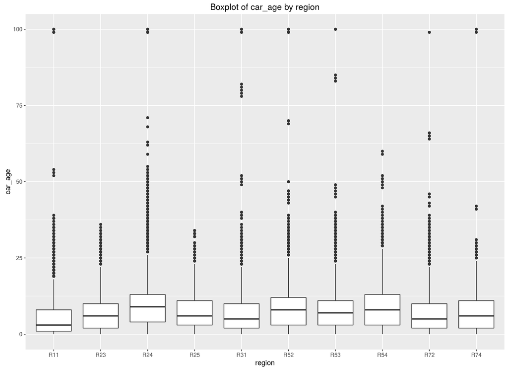

```r
ggplot(policy1_dt) +
    geom_boxplot(aes(x = region, y = car_age)) +
    ggtitle("Boxplot of car_age by region")
```

We may need to filter out cars that are exceptionally old.

## 2.3 Claim Data

First we look at a histogram of the individual claims without aggregating them by policy.

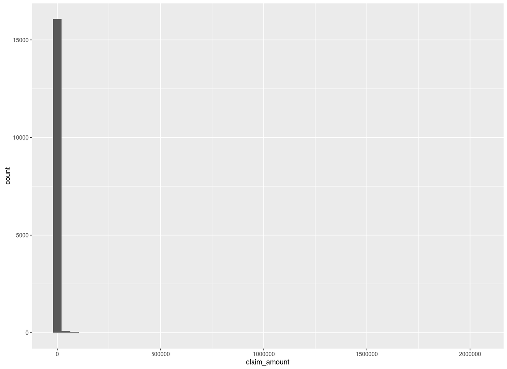

```r
ggplot(claims1_dt) +
    geom_histogram(aes(x = claim_amount), bins = 50)
```

This does not tell us much due to the skewed nature of the claims, so we instead look at all claims below EUR 25,000:

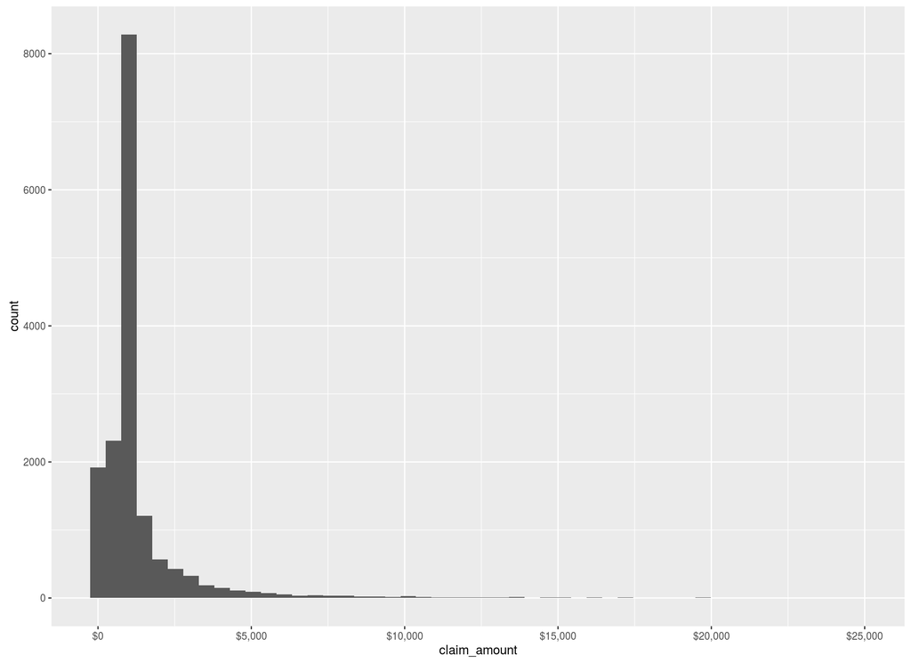

```r
ggplot(claims1_dt[claim_amount < 25000]) +
    geom_histogram(aes(x = claim_amount), bins = 50) +
    scale_x_continuous(label = dollar)
```

Claims above 25,000 are so skewed that we look at these on a separate plot with a logscale on the x-axis.

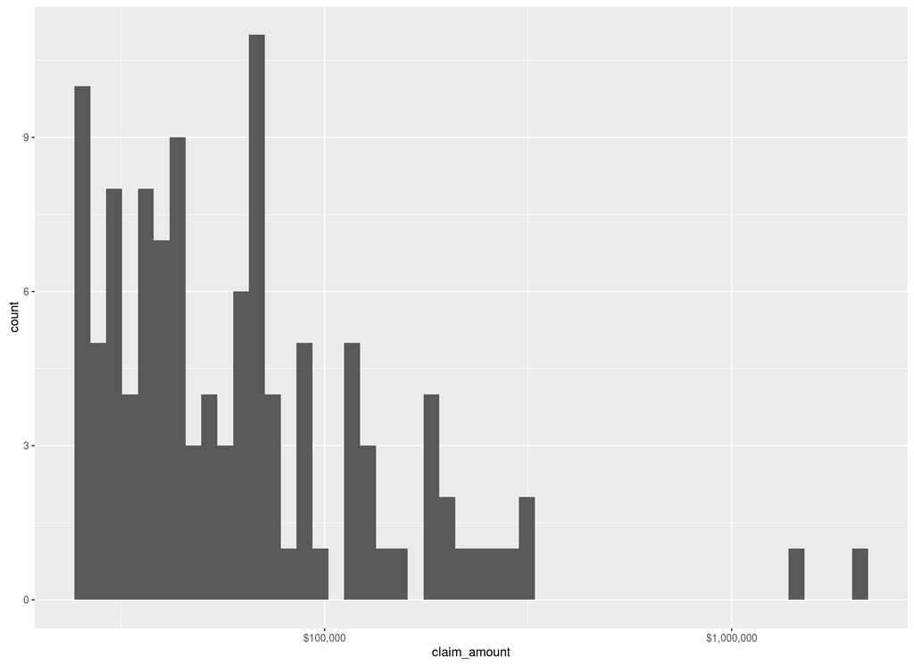

```r
ggplot(claims1_dt[claim_amount >= 25000]) +
    geom_histogram(aes(x = claim_amount), bins = 50) +
    scale_x_log10(label = dollar)
```

To get a sense of the skew in terms of the right tail, we look at a cumulative density plot of the claim amounts:

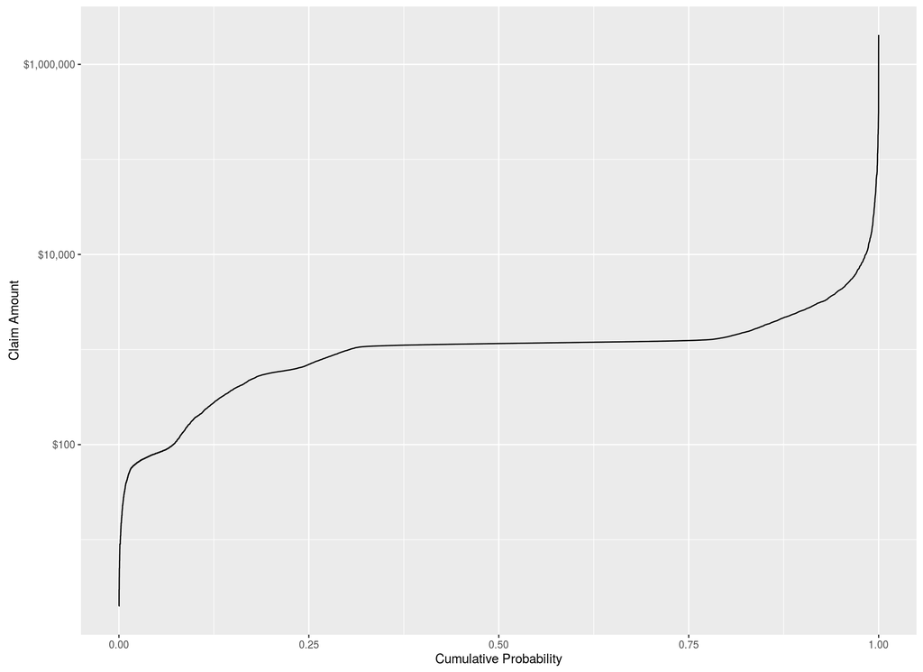

```r
ggplot(claims1_dt) +
    geom_line(aes(x = seq_along(claim_amount) / length(claim_amount)
                 ,y = sort(claim_amount))) +
    scale_y_log10(label = dollar) +
    xlab("Cumulative Probability") +
    ylab("Claim Amount")
```

### 2.3.1 Aggregate Claims by Policy

We now add up all the claims on a single policy and treat them as a single amount.

```r
claims_amount_dt <- claims1_dt %>%
    group_by(policy_id) %>%
    summarise(num_claim    = length(claim_amount)
             ,total_amount = sum(claim_amount)) %>%
    arrange(-total_amount, -num_claim)

policyclaim_dt <- policy1_dt %>%
    left_join(claims_amount_dt, by = 'policy_id') %>%
    mutate(total_amount = replace(total_amount, is.na(total_amount), 0))
```

Now we look at the total claims per policy.

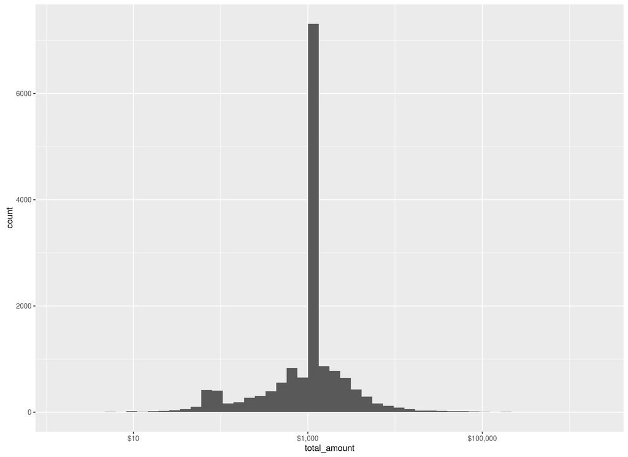

```r
ggplot(claims_amount_dt) +
    geom_histogram(aes(x = total_amount), bins = 50) +
    scale_x_log10(label = dollar)
```

We first check that the merge worked properly by ensuring that `claim_count` and `num_claim` are the same.

```r
policyclaim_dt %>%
    filter(claim_count != num_claim) %>%
    print
```

```
## Source: local data table [0 x 12]
##
## # tbl_dt [0 x 12]
## # ... with 12 variables: policy_id <int>, claim_count <int>, exposure <dbl>,
## #   power <fctr>, car_age <int>, driver_age <int>, brand <fctr>, gas <fctr>,
## #   region <fctr>, density <int>, num_claim <int>, total_amount <dbl>
```

We look at the cumulative claims per policy.

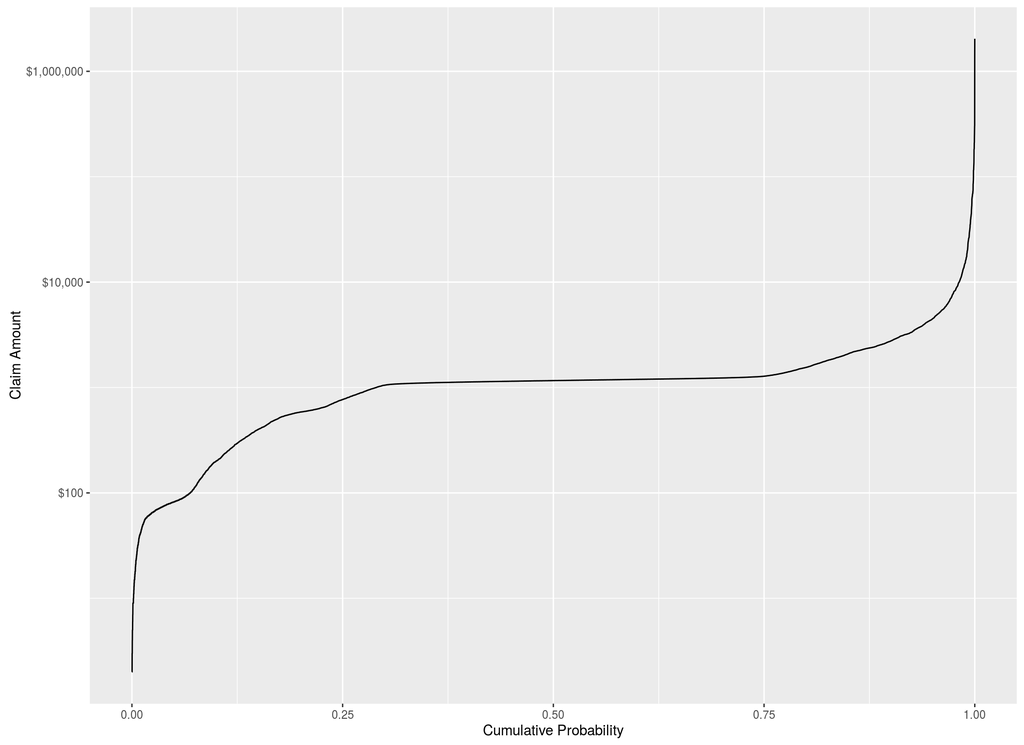

```r
ggplot(claims_amount_dt) +
    geom_line(aes(x = seq_along(total_amount) / length(total_amount)
                 ,y = sort(total_amount))) +
    scale_y_log10(label = dollar) +
    xlab("Cumulative Probability") +
    ylab("Claim Amount")
```

### 2.3.2 claimtotal by region

We do a boxplot of the total claims by region. We first will plot with all the claims to see if there is a regional pattern in the larger claims as we expect these amounts will dominate any visuals.

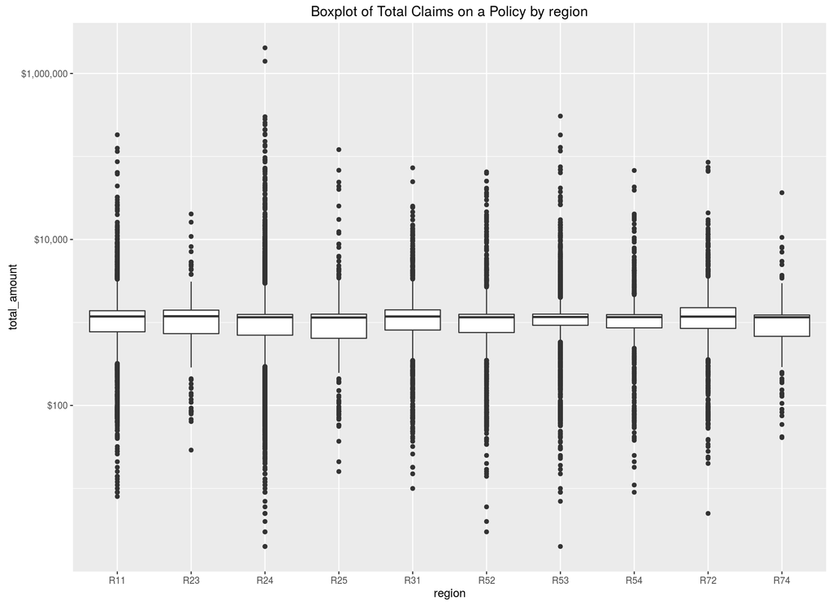

```r
ggplot(policyclaim_dt[total_amount > 0]) +
    geom_boxplot(aes(x = region, y = total_amount)) +
    scale_y_log10(label = dollar) +
    ggtitle("Boxplot of Total Claims on a Policy by region")
```

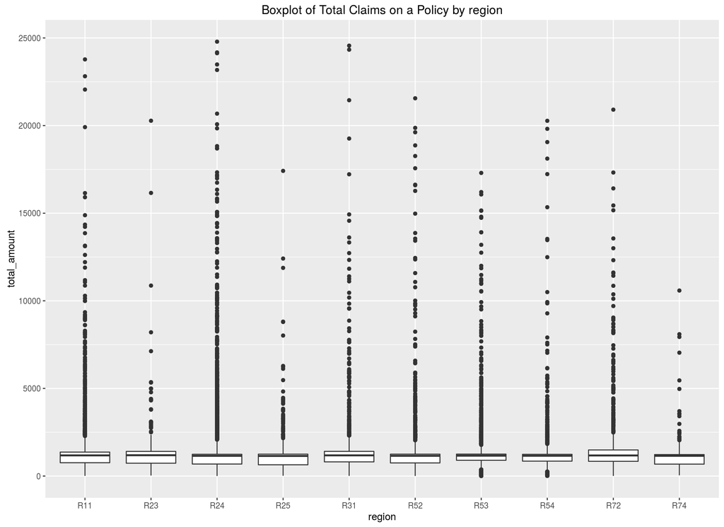

```r
ggplot(policyclaim_dt[total_amount > 0 & total_amount < 25000]) +
    geom_boxplot(aes(x = region, y = total_amount)) +
#    scale_y_log10(label = dollar) +
    ggtitle("Boxplot of Total Claims on a Policy by region")
```

### 2.3.3 Power-law Scaling

We look at the log-log plot of claim size against the cumulative number of claims of at least the size to investigate if the claim frequency obeys a power law.

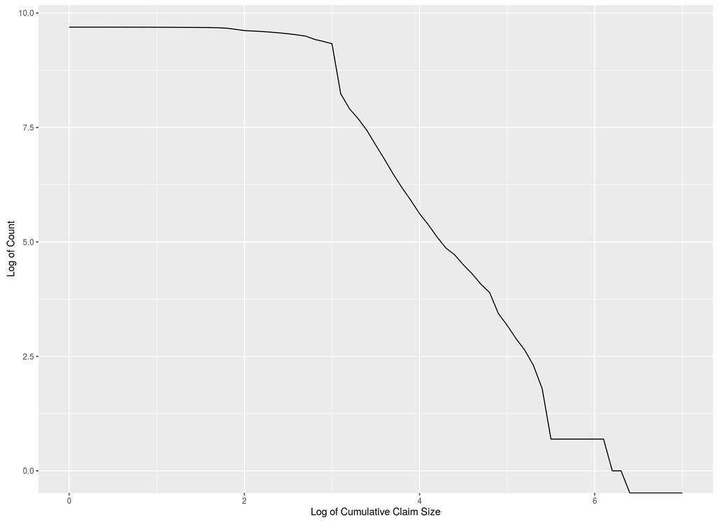

```r
logclaimsize_seq <- seq(0, 7, by = 0.1)

powerlaw_dt <- data.table(
    logsize = logclaimsize_seq
   ,count   = sapply(logclaimsize_seq
                    ,function(iter_m)
                         nrow(claims1_dt[claim_amount > 10^iter_m]))
)

ggplot(powerlaw_dt) +
    geom_line(aes(x = logsize, y = log(count))) +
    xlab("Log of Cumulative Claim Size") +
    ylab("Log of Count")
```

For claims about 1,000 ($\log \text{Claim} = 3$) a straight line could do a good job of fitting the curve, so we look at that

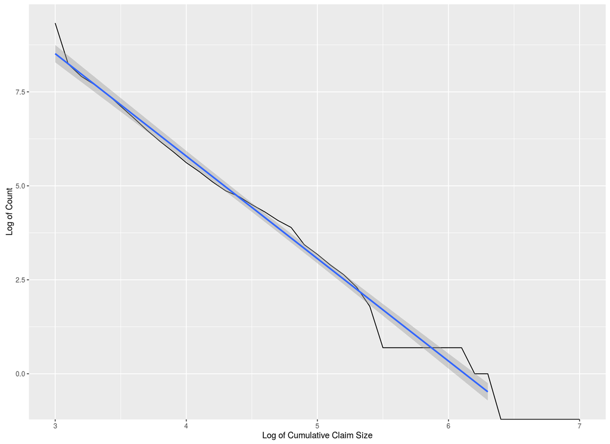

```r
ggplot(powerlaw_dt[logsize >= 3]) +
    geom_line(aes(x = logsize, y = log(count))) +
    geom_smooth(aes(x = logsize, y = log(count)), method = 'lm', se = TRUE) +
    xlab("Log of Cumulative Claim Size") +
    ylab("Log of Count")
```

Encouraged by the above plots, we will model part of the claim distribution with a power law - probably to work on the likelihood of larger claims.

# 3 Data Cleaning and Feature Creation

We now turn our attention to data cleaning and feature creation in the data. We do not have any premium information for the policy data, and may wish to convert some of the features from continuous to categorical - especially for variables such as age where we expect a non-linear influence on the output.

We may exclude data from the analysis if they are outliers.

## 3.1 Feature Creation

We aggregate a few of the continuous features that are unlikely to have any kind of linear response in terms of the data: `driver_age`, `car_age` and `density`.

We have picked a somewhat arbitrary set of cutoffs to discretise the variables for these three variables and will check their use in the models we build.

```r
policy1_dt[, cat_driver_age := cut(driver_age
                                  ,c(17,22,26,42,74,Inf))]
policy1_dt[, cat_car_age    := cut(car_age
                                  ,c(0,1,4,15,Inf)
                                  ,include.lowest = TRUE)]
policy1_dt[, cat_density    := cut(density
                                  ,c(0,40,200,500,4500,Inf)
                                  ,include.lowest = TRUE)]
```